# Fourier against von Mises: every real dataset

FoMo models the direction of each move with one of two directional models:

- **von Mises** (Clarke, Hunt & Hughes, 2022a): a weight for each of a few preferred directions, each a von Mises bump of fixed width.
- **Fourier-124**: a smooth curve made of the first, second and fourth harmonics (a {cos, sin} pair each), added to an item’s log-weight. The default since October 2026.

Both were fitted to every real dataset with everything else the same (the default priors and centring, 4 chains of 1000 warmup and 1000 sampling iterations) by `../../fit_models/fit_models.R`, then compared with `fomo_compare()` by `../compare_models.R`. This page reads those results and fits; nothing is refitted.

Code: `fourier_versus_vonmises.R`.

```r
source("../../../../functions/set_up_FoMo.R")
```

```
[1] "set_up_FoMo.R: random seed set to 65 (FOMO_SEED)"
```

```r
source("../../fit_models/fit_settings.R")

datasets <- c("kristjansson2014", "hughes2024rsos", "clarke2022qjep", "bhat2025msc",
              "tagu2022cog", "magerlfuller2026app")
models <- c(fourier124 = "Fourier-124", vonmises = "von Mises")

require_example_fits(as.vector(outer(datasets, names(models), paste, sep = "_")))

# fomo_compare() for every dataset, from compare_models.R
comparison <- read_csv(file.path(COMPARISON_DIR, "model_comparison.csv"), show_col_types = FALSE) |>
  filter(dataset %in% datasets, model %in% names(models)) |>
  mutate(dataset = factor(dataset, levels = datasets),
         model = factor(models[model], levels = models)) |>
  arrange(dataset, model)
```

## 1 The comparison

One row per dataset and model. `deterministic`: how often the model’s most likely item is the one selected (leaving out each trial’s first selection and any forced last one); `nn`: the same for the nearest-neighbour rule, and `gain_nn` the model’s gain over it. `elpd_diff` is the leave-one-trial-out (loo) difference from the better model, with its standard error; `pct_high_k` the percentage of trials whose Pareto k is above 0.7 (where loo is less reliable), and `robust` whether the difference holds without those trials.

```r
format_compare(comparison, group = "dataset",
               columns = c("dataset", "model", "deterministic", "nn", "gain_nn", "elpd_diff",
                           "se_diff", "pct_high_k", "robust"))
```

| dataset | model | deterministic | nn | gain_nn | elpd_diff | se_diff | pct_high_k | robust |
| --- | --- | --- | --- | --- | --- | --- | --- | --- |
| kristjansson2014 | Fourier-124 | 0.674 | 0.533 | 0.141 | 0.0 | 0.0 | 1.4 | TRUE |
| kristjansson2014 | von Mises | 0.660 | 0.533 | 0.127 | -906.8 | 61.7 | 1.1 | TRUE |
| hughes2024rsos | Fourier-124 | 0.727 | 0.607 | 0.120 | 0.0 | 0.0 | 0.6 | TRUE |
| hughes2024rsos | von Mises | 0.716 | 0.607 | 0.109 | -1413.9 | 70.4 | 0.9 | TRUE |
| clarke2022qjep | Fourier-124 | 0.694 | 0.592 | 0.102 | 0.0 | 0.0 | 2.1 | TRUE |
| clarke2022qjep | von Mises | 0.684 | 0.592 | 0.092 | -2532.8 | 118.1 | 1.5 | TRUE |
| bhat2025msc | Fourier-124 | 0.695 | 0.579 | 0.117 | 0.0 | 0.0 | 13.0 | TRUE |
| bhat2025msc | von Mises | 0.685 | 0.579 | 0.107 | -491.4 | 51.3 | 8.9 | TRUE |
| tagu2022cog | Fourier-124 | 0.624 | 0.521 | 0.103 | 0.0 | 0.0 | 8.9 | TRUE |
| tagu2022cog | von Mises | 0.622 | 0.521 | 0.101 | -165.1 | 30.1 | 7.1 | TRUE |
| magerlfuller2026app | Fourier-124 | 0.548 | 0.209 | 0.339 | 0.0 | 0.0 | 0.0 | TRUE |
| magerlfuller2026app | von Mises | 0.545 | 0.209 | 0.336 | -75.8 | 15.6 | 0.0 | TRUE |

Fourier-124 is better on every dataset, by between 5 and 21 standard errors. The datasets differ a lot in size, so per trial:

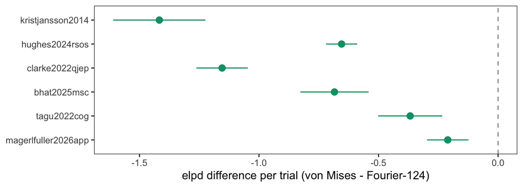

Figure 1: The loo difference per trial between von Mises and Fourier-124 (below 0: von Mises is worse), with 2 standard errors.

```r
# the loo difference per trial, so datasets of different sizes are on one
# scale (loo leaves out one trial at a time)
n_trials <- map_int(set_names(datasets), \(ds) {
  nrow(readRDS(file.path(FITS_DIR, paste0(ds, "_fourier124_loo.rds")))$pointwise)
})

comparison |>
  filter(model == "von Mises") |>
  mutate(n_trials = n_trials[as.character(dataset)],
         per_trial = elpd_diff / n_trials,
         se = se_diff / n_trials) |>
  ggplot(aes(per_trial, fct_rev(dataset))) +
  geom_vline(xintercept = 0, linetype = "dashed", alpha = 0.5) +
  geom_pointrange(aes(xmin = per_trial - 2 * se, xmax = per_trial + 2 * se),
                  colour = MODEL_COLOURS[2]) +
  labs(x = "elpd difference per trial (von Mises - Fourier-124)", y = NULL)
```

The gain in accuracy is small (at most about 1.5 points): which item each model rates most likely mostly agrees, so the loo difference comes mainly from how much probability each gives the item that was selected.

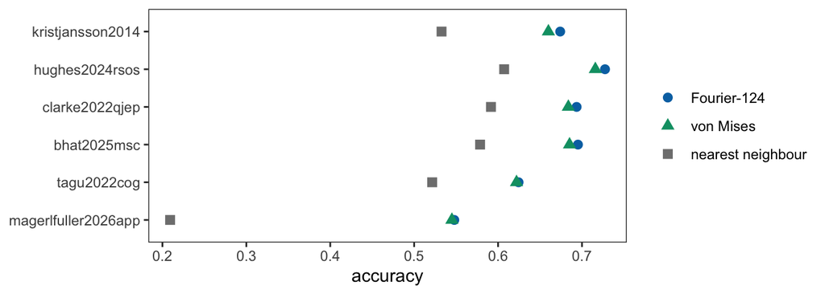

Figure 2: Accuracy of each model and of the nearest-neighbour rule, per dataset.

```r
# deterministic accuracy (the model's most likely item is the one
# selected), with the nearest-neighbour rule on the same selections
comparison |>
  select(dataset, model, deterministic) |>
  bind_rows(distinct(comparison, dataset, deterministic = nn) |> mutate(model = "nearest neighbour")) |>
  mutate(model = factor(model, levels = c(models, "nearest neighbour"))) |>
  ggplot(aes(deterministic, fct_rev(dataset), colour = model, shape = model)) +
  geom_point(size = 2.5) +
  scale_colour_manual(values = c(MODEL_COLOURS[1:2], "grey50")) +
  labs(x = "accuracy", y = NULL, colour = NULL, shape = NULL)
```

Stacking weights split the predictions between the models: the weights of the mixture of the two models’ predictive distributions that best predicts held-out trials. They are not the probability that each model is right. Von Mises keeps 9-20% of the weight on every dataset, despite being thousands of elpd behind on some: a mixture gains from von Mises if it predicts some trials better than Fourier-124, even when it is worse overall. Which trials those are hasn’t been checked yet, so don’t read much into the weights.

[figure not shown]

Figure 3: Stacking weights of the two models, per dataset.

```r
# stacking weights: the weights of the mixture of the two models' loo
# predictive distributions that predicts held-out trials best
comparison |>
  ggplot(aes(stacking, fct_rev(dataset), fill = model)) +
  geom_col(width = 0.7) +
  scale_fill_manual(values = MODEL_COLOURS[1:2]) +
  scale_x_continuous(expand = c(0, 0)) +
  labs(x = "stacking weight", y = NULL, fill = NULL)
```

## 2 The directional curves

Why Fourier-124 fits better: the directional preferences each model finds, as log-weights against the absolute direction of the move.

```r
# each model's directional log-weight curve (centred), from 200 posterior
# draws of each fit: only the directional parameters are read
directional_curves <- function(ds, model) {
  fit <- readRDS(file.path(FITS_DIR, paste0(ds, "_", model, ".rds")))
  d <- import_dataset(ds)
  cond_labels <- levels(d$found$condition)
  # the names from the metadata: get_variables() turns every draw into a
  # data frame first, too big for fits that stored per-selection P/W
  vars <- fit$metadata()$model_params
  post <- list(vonmises = extract_vonmises(fit, vars, cond_labels),
               fourier = extract_fourier(fit, vars, cond_labels))
  out <- compute_directional_curve(post, draws = sample(posterior::ndraws(fit$draws("lp__")), 200)) |>
    mutate(dataset = ds, model = models[model])
  # each fit holds all its draws (GBs): free it before reading the next, or
  # the 12 fits reach R's 16 GB vector limit
  rm(fit, post)
  gc(verbose = FALSE)
  out
}

curves <- crossing(ds = datasets, model = names(models)) |>
  pmap(directional_curves) |>
  list_rbind()
```

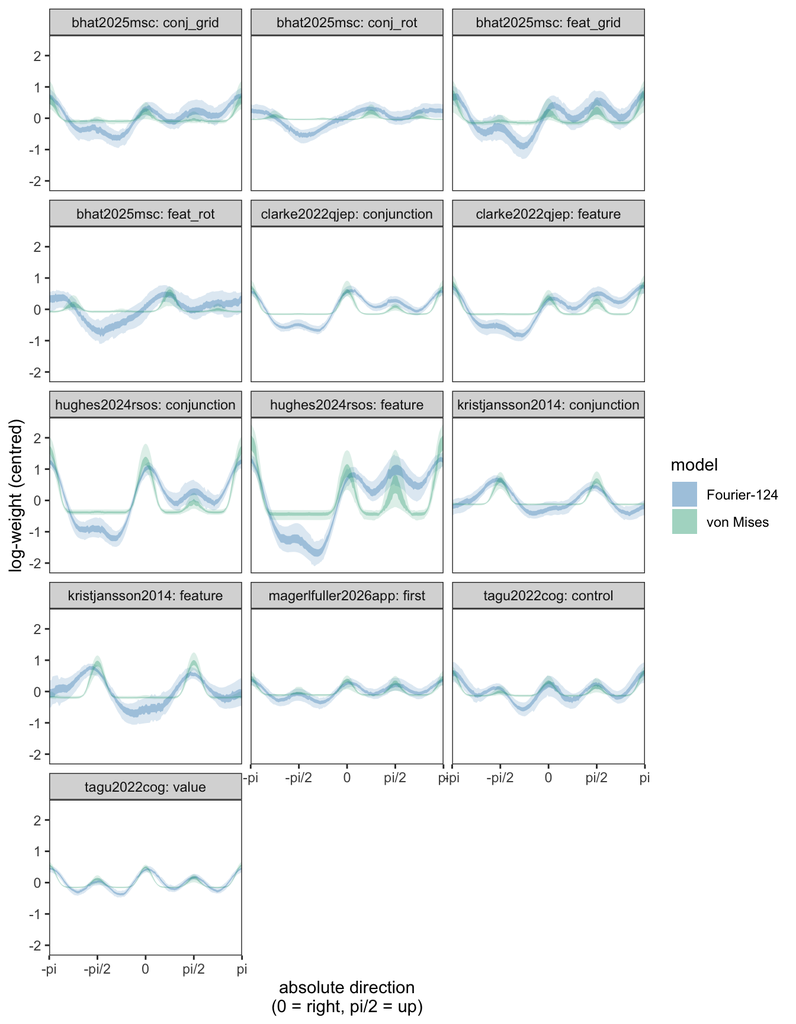

Figure 4: Directional log-weight curves (centred), 53% and 97% HPDIs, for each dataset and condition.

```r
curves |>
  mutate(condition = paste0(dataset, ": ", condition),
         model = factor(model, levels = models)) |>
  plot_post_directional_curves() +
  facet_wrap(~condition, ncol = 3)
```